# Eco Geno 2/27/17

R Kirsten Tyler

2/27/2017

### Modeling our data

Previously, Melissa did this:

Update on Making and Mapping to a new reference transcriptome: - Concatenated fastq files from 4 individuals (over 200M reads) both sick and healthy. - Digital normalization by kmer to make a smaller file size (8.7% of original size). - Ran Trinity with really low max-memory and CPUs so that it would complete without crashing - Predicted ORFs with TransDecoder.pl script. - Evaluated contig stats to find that they were fewer, longer contigs. - Mapped reads to this new assembly. - Extracted read counts - Assembled read counts table.

# Today!

1. Move new data
2. DESeq 2
- 5 models
3. Your models

Our new assembly: Melissa used the longest isoform But longest isoform does not equal best isoform However, by taking the longest one, we are recovering more of our reads

We are using [this tutorial] (https://www.bioconductor.org/packages/devel/bioc/vignettes/DESeq2/inst/doc/DESeq2_pdf.pdf)

```r
setwd("~/Documents/Ecological Genomics PBIO381/")

library(DESeq2)
```

```r
library(ggplot2)


countsTable <- read.delim('countsdata_trim2.txt', header = TRUE, stringsAsFactors = TRUE, row.names = 1)
countData <- as.matrix(countsTable)
head(countData)
```

```
##                                                            I03_5.08_S_2
## TRINITY_DN10003_c0_g1_TRINITY_DN10003_c0_g1_i1_g.850_m.850            4
## TRINITY_DN10009_c0_g1_TRINITY_DN10009_c0_g1_i1_g.851_m.851           17
## TRINITY_DN1000_c0_g1_TRINITY_DN1000_c0_g1_i1_g.101_m.101              0
## TRINITY_DN10011_c0_g1_TRINITY_DN10011_c0_g1_i1_g.852_m.852           34
## TRINITY_DN10021_c0_g1_TRINITY_DN10021_c0_g1_i1_g.853_m.853           34
## TRINITY_DN10033_c0_g1_TRINITY_DN10033_c0_g1_i1_g.855_m.855          141
##                                                            I03_5.11_S_4
## TRINITY_DN10003_c0_g1_TRINITY_DN10003_c0_g1_i1_g.850_m.850           26
## TRINITY_DN10009_c0_g1_TRINITY_DN10009_c0_g1_i1_g.851_m.851            0
## TRINITY_DN1000_c0_g1_TRINITY_DN1000_c0_g1_i1_g.101_m.101             11
## TRINITY_DN10011_c0_g1_TRINITY_DN10011_c0_g1_i1_g.852_m.852            0
## TRINITY_DN10021_c0_g1_TRINITY_DN10021_c0_g1_i1_g.853_m.853            5
## TRINITY_DN10033_c0_g1_TRINITY_DN10033_c0_g1_i1_g.855_m.855           85
##                                                            I07_5.08_S_1
## TRINITY_DN10003_c0_g1_TRINITY_DN10003_c0_g1_i1_g.850_m.850          246
## TRINITY_DN10009_c0_g1_TRINITY_DN10009_c0_g1_i1_g.851_m.851            0
## TRINITY_DN1000_c0_g1_TRINITY_DN1000_c0_g1_i1_g.101_m.101            262
## TRINITY_DN10011_c0_g1_TRINITY_DN10011_c0_g1_i1_g.852_m.852           61
## TRINITY_DN10021_c0_g1_TRINITY_DN10021_c0_g1_i1_g.853_m.853            0
## TRINITY_DN10033_c0_g1_TRINITY_DN10033_c0_g1_i1_g.855_m.855            0
##                                                            I08_5.08_H_0
## TRINITY_DN10003_c0_g1_TRINITY_DN10003_c0_g1_i1_g.850_m.850            0
## TRINITY_DN10009_c0_g1_TRINITY_DN10009_c0_g1_i1_g.851_m.851            0
## TRINITY_DN1000_c0_g1_TRINITY_DN1000_c0_g1_i1_g.101_m.101             55
## TRINITY_DN10011_c0_g1_TRINITY_DN10011_c0_g1_i1_g.852_m.852            0
## TRINITY_DN10021_c0_g1_TRINITY_DN10021_c0_g1_i1_g.853_m.853            0
## TRINITY_DN10033_c0_g1_TRINITY_DN10033_c0_g1_i1_g.855_m.855           29
##                                                            I08_5.11_S_1
## TRINITY_DN10003_c0_g1_TRINITY_DN10003_c0_g1_i1_g.850_m.850            0
## TRINITY_DN10009_c0_g1_TRINITY_DN10009_c0_g1_i1_g.851_m.851            0
## TRINITY_DN1000_c0_g1_TRINITY_DN1000_c0_g1_i1_g.101_m.101              0
## TRINITY_DN10011_c0_g1_TRINITY_DN10011_c0_g1_i1_g.852_m.852            0
## TRINITY_DN10021_c0_g1_TRINITY_DN10021_c0_g1_i1_g.853_m.853            0
## TRINITY_DN10033_c0_g1_TRINITY_DN10033_c0_g1_i1_g.855_m.855            0
##                                                            I08_5.14_S_1
## TRINITY_DN10003_c0_g1_TRINITY_DN10003_c0_g1_i1_g.850_m.850           68
## TRINITY_DN10009_c0_g1_TRINITY_DN10009_c0_g1_i1_g.851_m.851            0
## TRINITY_DN1000_c0_g1_TRINITY_DN1000_c0_g1_i1_g.101_m.101              0
## TRINITY_DN10011_c0_g1_TRINITY_DN10011_c0_g1_i1_g.852_m.852            0
```

[output cut: 484 more lines]

```
## TRINITY_DN10033_c0_g1_TRINITY_DN10033_c0_g1_i1_g.855_m.855            0
##                                                            I37_6.18_H_0
## TRINITY_DN10003_c0_g1_TRINITY_DN10003_c0_g1_i1_g.850_m.850            7
## TRINITY_DN10009_c0_g1_TRINITY_DN10009_c0_g1_i1_g.851_m.851          111
## TRINITY_DN1000_c0_g1_TRINITY_DN1000_c0_g1_i1_g.101_m.101             54
## TRINITY_DN10011_c0_g1_TRINITY_DN10011_c0_g1_i1_g.852_m.852            0
## TRINITY_DN10021_c0_g1_TRINITY_DN10021_c0_g1_i1_g.853_m.853            0
## TRINITY_DN10033_c0_g1_TRINITY_DN10033_c0_g1_i1_g.855_m.855            8
##                                                            I38_6.12_H_0
## TRINITY_DN10003_c0_g1_TRINITY_DN10003_c0_g1_i1_g.850_m.850           10
## TRINITY_DN10009_c0_g1_TRINITY_DN10009_c0_g1_i1_g.851_m.851            6
## TRINITY_DN1000_c0_g1_TRINITY_DN1000_c0_g1_i1_g.101_m.101              7
## TRINITY_DN10011_c0_g1_TRINITY_DN10011_c0_g1_i1_g.852_m.852           22
## TRINITY_DN10021_c0_g1_TRINITY_DN10021_c0_g1_i1_g.853_m.853            2
## TRINITY_DN10033_c0_g1_TRINITY_DN10033_c0_g1_i1_g.855_m.855           10
```

```r
conds <- read.delim("cols_data_trim.txt", header = TRUE, stringsAsFactors = TRUE, row.names = 1)
head(conds)
```

```
##              indiv   day health score location
## I03_5.08_S_2     3 day03      S     2      int
## I03_5.11_S_4     3 day06      S     4      int
## I07_5.08_S_1     7 day03      S     1      int
## I08_5.08_H_0     8 day03      H     0      int
## I08_5.11_S_1     8 day06      S     1      int
## I08_5.14_S_1     8 day09      S     1      int
```

```r
colData <- as.data.frame(conds)
head(colData)
```

```
##              indiv   day health score location
## I03_5.08_S_2     3 day03      S     2      int
## I03_5.11_S_4     3 day06      S     4      int
## I07_5.08_S_1     7 day03      S     1      int
## I08_5.08_H_0     8 day03      H     0      int
## I08_5.11_S_1     8 day06      S     1      int
## I08_5.14_S_1     8 day09      S     1      int
```

# MODEL NUMBER 1: TEST EFFECT OF HEALTH CONTROLLING FOR LOCATION

```r
dds <- DESeqDataSetFromMatrix(countData = countData, colData = colData, design = ~ location + health)
# Here, we are asking: what's the effect of health given the location?
# so we are focusing in on the LAST term as the one that is the main effect
# in this typical model, the "health effect" represents the overall effect of health status, controlling for differences due to location




dim(dds)
```

```
## [1] 13053    77
```

```r
dds <- dds[ rowSums(counts(dds)) > 100, ]
dim(dds)
```

```
## [1] 12954    77
```

```r
# For practice, let's work with fewer genes so that the models can run faster...
dds <- dds[sample(nrow(dds), 1200), ] #randomly sample of 1200 rows from our 12000 row data matrix. when we do our real analyses, we won't want to sample - we'll want to use the entire data matrix
dim(dds)
```

```
## [1] 1200   77
```

```r
colData(dds)$health <- factor(colData(dds)$health, levels=c("H","S")) #sets that "healthy is the reference

dds <- DESeq(dds)
```

```
## -- replacing outliers and refitting for 92 genes
## -- DESeq argument 'minReplicatesForReplace' = 7
## -- original counts are preserved in counts(dds)
```

```r
res <- results(dds)
res <- res[order(res$padj),] #this sorts our results by the adjusted p-value. Nice!
head(res)
```

```
## log2 fold change (MAP): health S vs H
## Wald test p-value: health S vs H
## DataFrame with 6 rows and 6 columns
##                                                                 baseMean
##                                                                <numeric>
## TRINITY_DN46709_c0_g1_TRINITY_DN46709_c0_g1_i2_g.23139_m.23139  99.15378
## TRINITY_DN44708_c0_g1_TRINITY_DN44708_c0_g1_i1_g.17578_m.17578 287.05624
## TRINITY_DN35583_c0_g1_TRINITY_DN35583_c0_g1_i1_g.5795_m.5795    58.62103
## TRINITY_DN47215_c1_g4_TRINITY_DN47215_c1_g4_i3_g.25054_m.25054 685.13760
## TRINITY_DN47315_c4_g1_TRINITY_DN47315_c4_g1_i2_g.25566_m.25566 770.87003
## TRINITY_DN46402_c0_g1_TRINITY_DN46402_c0_g1_i1_g.22193_m.22193 180.93677
##                                                                log2FoldChange
##                                                                     <numeric>
## TRINITY_DN46709_c0_g1_TRINITY_DN46709_c0_g1_i2_g.23139_m.23139      2.9491467
## TRINITY_DN44708_c0_g1_TRINITY_DN44708_c0_g1_i1_g.17578_m.17578      0.9713138
## TRINITY_DN35583_c0_g1_TRINITY_DN35583_c0_g1_i1_g.5795_m.5795        1.7904991
## TRINITY_DN47215_c1_g4_TRINITY_DN47215_c1_g4_i3_g.25054_m.25054      1.4926836
## TRINITY_DN47315_c4_g1_TRINITY_DN47315_c4_g1_i2_g.25566_m.25566      1.1407144
## TRINITY_DN46402_c0_g1_TRINITY_DN46402_c0_g1_i1_g.22193_m.22193      1.3553148
##                                                                    lfcSE
##                                                                <numeric>
## TRINITY_DN46709_c0_g1_TRINITY_DN46709_c0_g1_i2_g.23139_m.23139 0.5122780
## TRINITY_DN44708_c0_g1_TRINITY_DN44708_c0_g1_i1_g.17578_m.17578 0.2000075
## TRINITY_DN35583_c0_g1_TRINITY_DN35583_c0_g1_i1_g.5795_m.5795   0.3765950
## TRINITY_DN47215_c1_g4_TRINITY_DN47215_c1_g4_i3_g.25054_m.25054 0.3168103
## TRINITY_DN47315_c4_g1_TRINITY_DN47315_c4_g1_i2_g.25566_m.25566 0.2452305
## TRINITY_DN46402_c0_g1_TRINITY_DN46402_c0_g1_i1_g.22193_m.22193 0.3236965
##                                                                     stat
##                                                                <numeric>
## TRINITY_DN46709_c0_g1_TRINITY_DN46709_c0_g1_i2_g.23139_m.23139  5.756927
## TRINITY_DN44708_c0_g1_TRINITY_DN44708_c0_g1_i1_g.17578_m.17578  4.856387
## TRINITY_DN35583_c0_g1_TRINITY_DN35583_c0_g1_i1_g.5795_m.5795    4.754442
## TRINITY_DN47215_c1_g4_TRINITY_DN47215_c1_g4_i3_g.25054_m.25054  4.711600
## TRINITY_DN47315_c4_g1_TRINITY_DN47315_c4_g1_i2_g.25566_m.25566  4.651600
## TRINITY_DN46402_c0_g1_TRINITY_DN46402_c0_g1_i1_g.22193_m.22193  4.186992
##                                                                      pvalue
##                                                                   <numeric>
## TRINITY_DN46709_c0_g1_TRINITY_DN46709_c0_g1_i2_g.23139_m.23139 8.565917e-09
## TRINITY_DN44708_c0_g1_TRINITY_DN44708_c0_g1_i1_g.17578_m.17578 1.195471e-06
## TRINITY_DN35583_c0_g1_TRINITY_DN35583_c0_g1_i1_g.5795_m.5795   1.989948e-06
## TRINITY_DN47215_c1_g4_TRINITY_DN47215_c1_g4_i3_g.25054_m.25054 2.457791e-06
## TRINITY_DN47315_c4_g1_TRINITY_DN47315_c4_g1_i2_g.25566_m.25566 3.293688e-06
## TRINITY_DN46402_c0_g1_TRINITY_DN46402_c0_g1_i1_g.22193_m.22193 2.826753e-05
##                                                                        padj
##                                                                   <numeric>
## TRINITY_DN46709_c0_g1_TRINITY_DN46709_c0_g1_i2_g.23139_m.23139 4.642727e-06
## TRINITY_DN44708_c0_g1_TRINITY_DN44708_c0_g1_i1_g.17578_m.17578 3.239725e-04
## TRINITY_DN35583_c0_g1_TRINITY_DN35583_c0_g1_i1_g.5795_m.5795   3.330307e-04
## TRINITY_DN47215_c1_g4_TRINITY_DN47215_c1_g4_i3_g.25054_m.25054 3.330307e-04
## TRINITY_DN47315_c4_g1_TRINITY_DN47315_c4_g1_i2_g.25566_m.25566 3.570358e-04
## TRINITY_DN46402_c0_g1_TRINITY_DN46402_c0_g1_i1_g.22193_m.22193 2.553500e-03
```

```r
# log2 fold change (MAP): health S vs H
# Wald test p-value: health S vs H
# DataFrame with 6 rows and 6 columns
# baseMean log2FoldChange     lfcSE

summary(res)
```

```
##
## out of 1199 with nonzero total read count
## adjusted p-value < 0.1
## LFC > 0 (up)     : 20, 1.7%
## LFC < 0 (down)   : 3, 0.25%
## outliers [1]     : 34, 2.8%
## low counts [2]   : 624, 52%
## (mean count < 17)
## [1] see 'cooksCutoff' argument of ?results
## [2] see 'independentFiltering' argument of ?results
```

```r
# out of 1199 with nonzero total read count
# adjusted p-value < 0.1
# LFC > 0 (up)     : 27, 2.3%
# LFC < 0 (down)   : 14, 1.2%
# outliers [1]     : 31, 2.6%
# low counts [2]   : 743, 62%
# (mean count < 25)
```

# MODEL NUMBER 2 - INTERACTIONS

```r
dds <- DESeqDataSetFromMatrix(countData = countData, colData = colData, design = ~ location + health + location:health) #now we are adding "interaction of location and health"

dim(dds)
```

```
## [1] 13053    77
```

```r
dds <- dds[ rowSums(counts(dds)) > 100, ]

dds <- dds[sample(nrow(dds), 1200), ]
dim(dds)
```

```
## [1] 1200   77
```

```r
colData(dds)$health <- factor(colData(dds)$health, levels=c("H","S"))  #sets that "healthy is the reference

dds <- DESeq(dds, parallel=T) #parallel = using two cores on my computer = wicked fast!!
```

```
## -- replacing outliers and refitting for 85 genes
## -- DESeq argument 'minReplicatesForReplace' = 7
## -- original counts are preserved in counts(dds)
```

```r
resultsNames(dds)
```

```
## [1] "Intercept"           "location_sub_vs_int" "health_S_vs_H"
## [4] "locationsub.healthS"
```

```r
res <- results(dds, name="locationsub.healthS")
res <- res[order(res$padj),]
head(res)
```

```
## log2 fold change (MLE): locationsub.healthS
## Wald test p-value: locationsub.healthS
## DataFrame with 6 rows and 6 columns
##                                                                  baseMean
##                                                                 <numeric>
## TRINITY_DN51218_c0_g1_TRINITY_DN51218_c0_g1_i1_g.26230_m.26230  10.095370
## TRINITY_DN42526_c5_g1_TRINITY_DN42526_c5_g1_i1_g.13026_m.13026  55.536185
## TRINITY_DN46198_c3_g1_TRINITY_DN46198_c3_g1_i2_g.21580_m.21580 597.030721
## TRINITY_DN46658_c0_g5_TRINITY_DN46658_c0_g5_i1_g.22979_m.22979 211.677206
## TRINITY_DN44465_c3_g1_TRINITY_DN44465_c3_g1_i1_g.17071_m.17071  19.410987
## TRINITY_DN27691_c0_g1_TRINITY_DN27691_c0_g1_i2_g.3062_m.3062     7.216519
##                                                                log2FoldChange
##                                                                     <numeric>
## TRINITY_DN51218_c0_g1_TRINITY_DN51218_c0_g1_i1_g.26230_m.26230     -24.231079
## TRINITY_DN42526_c5_g1_TRINITY_DN42526_c5_g1_i1_g.13026_m.13026      -8.912851
## TRINITY_DN46198_c3_g1_TRINITY_DN46198_c3_g1_i2_g.21580_m.21580       3.526953
## TRINITY_DN46658_c0_g5_TRINITY_DN46658_c0_g5_i1_g.22979_m.22979      -2.714970
## TRINITY_DN44465_c3_g1_TRINITY_DN44465_c3_g1_i1_g.17071_m.17071      -6.043034
## TRINITY_DN27691_c0_g1_TRINITY_DN27691_c0_g1_i2_g.3062_m.3062        -7.786055
##                                                                    lfcSE
##                                                                <numeric>
## TRINITY_DN51218_c0_g1_TRINITY_DN51218_c0_g1_i1_g.26230_m.26230 4.5333362
## TRINITY_DN42526_c5_g1_TRINITY_DN42526_c5_g1_i1_g.13026_m.13026 1.9059869
## TRINITY_DN46198_c3_g1_TRINITY_DN46198_c3_g1_i2_g.21580_m.21580 1.1467822
## TRINITY_DN46658_c0_g5_TRINITY_DN46658_c0_g5_i1_g.22979_m.22979 0.8850045
## TRINITY_DN44465_c3_g1_TRINITY_DN44465_c3_g1_i1_g.17071_m.17071 1.8820613
## TRINITY_DN27691_c0_g1_TRINITY_DN27691_c0_g1_i2_g.3062_m.3062   2.5348011
##                                                                     stat
##                                                                <numeric>
## TRINITY_DN51218_c0_g1_TRINITY_DN51218_c0_g1_i1_g.26230_m.26230 -5.345088
## TRINITY_DN42526_c5_g1_TRINITY_DN42526_c5_g1_i1_g.13026_m.13026 -4.676239
## TRINITY_DN46198_c3_g1_TRINITY_DN46198_c3_g1_i2_g.21580_m.21580  3.075522
## TRINITY_DN46658_c0_g5_TRINITY_DN46658_c0_g5_i1_g.22979_m.22979 -3.067748
## TRINITY_DN44465_c3_g1_TRINITY_DN44465_c3_g1_i1_g.17071_m.17071 -3.210859
## TRINITY_DN27691_c0_g1_TRINITY_DN27691_c0_g1_i2_g.3062_m.3062   -3.071663
##                                                                      pvalue
##                                                                   <numeric>
## TRINITY_DN51218_c0_g1_TRINITY_DN51218_c0_g1_i1_g.26230_m.26230 9.037333e-08
## TRINITY_DN42526_c5_g1_TRINITY_DN42526_c5_g1_i1_g.13026_m.13026 2.921838e-06
## TRINITY_DN46198_c3_g1_TRINITY_DN46198_c3_g1_i2_g.21580_m.21580 2.101347e-03
## TRINITY_DN46658_c0_g5_TRINITY_DN46658_c0_g5_i1_g.22979_m.22979 2.156787e-03
## TRINITY_DN44465_c3_g1_TRINITY_DN44465_c3_g1_i1_g.17071_m.17071 1.323387e-03
## TRINITY_DN27691_c0_g1_TRINITY_DN27691_c0_g1_i2_g.3062_m.3062   2.128698e-03
##                                                                        padj
##                                                                   <numeric>
## TRINITY_DN51218_c0_g1_TRINITY_DN51218_c0_g1_i1_g.26230_m.26230 0.0001047427
## TRINITY_DN42526_c5_g1_TRINITY_DN42526_c5_g1_i1_g.13026_m.13026 0.0016932050
## TRINITY_DN46198_c3_g1_TRINITY_DN46198_c3_g1_i2_g.21580_m.21580 0.2272468807
## TRINITY_DN46658_c0_g5_TRINITY_DN46658_c0_g5_i1_g.22979_m.22979 0.2272468807
## TRINITY_DN44465_c3_g1_TRINITY_DN44465_c3_g1_i1_g.17071_m.17071 0.2272468807
## TRINITY_DN27691_c0_g1_TRINITY_DN27691_c0_g1_i2_g.3062_m.3062   0.2272468807
```

```r
summary(res)
```

```
##
## out of 1199 with nonzero total read count
## adjusted p-value < 0.1
## LFC > 0 (up)     : 0, 0%
## LFC < 0 (down)   : 2, 0.17%
## outliers [1]     : 40, 3.3%
## low counts [2]   : 1, 0.083%
## (mean count < 0)
## [1] see 'cooksCutoff' argument of ?results
## [2] see 'independentFiltering' argument of ?results
```

# MODEL NUMBER 3 - GROUP DESIGNS can be used for contrasts of interest or interactions

```r
colData$group <- factor(paste0(colData$location, ".", colData$health, ".", colData$score)) #here we are pasting together different variables in which we are interested into a group. This helps us focus on subsets of data. We can focus on specific parts of data: a specific day, for example.
dds <- DESeqDataSetFromMatrix(countData = countData, colData = colData, design = ~ group)
dim(dds)
```

```
## [1] 13053    77
```

```r
dds <- dds[ rowSums(counts(dds)) > 100, ]

dds <- dds[sample(nrow(dds), 1200), ]
dim(dds)
```

```
## [1] 1200   77
```

```r
dds <- DESeq(dds, parallel=T)
```

```
## -- replacing outliers and refitting for 1200 genes
## -- DESeq argument 'minReplicatesForReplace' = 7
## -- original counts are preserved in counts(dds)
```

```r
resultsNames(dds)
```

```
##  [1] "Intercept"    "groupint.H.0" "groupint.S.1" "groupint.S.2"
##  [5] "groupint.S.3" "groupint.S.4" "groupint.S.5" "groupsub.H.0"
##  [9] "groupsub.S.1" "groupsub.S.2" "groupsub.S.3"
```

```r
# [1] "Intercept"    "groupint.H.0" "groupint.S.1" "groupint.S.2" "groupint.S.3" "groupint.S.4"
# [7] "groupint.S.5" "groupsub.H.0" "groupsub.S.1" "groupsub.S.2" "groupsub.S.3"

res <- results(dds, contrast=list( c("groupint.H.0","groupsub.H.0"), c("groupint.S.1","groupsub.S.1")), listValues=c(1/2, -1/2))



res <- res[order(res$padj),]
head(res)
```

```
## log2 fold change (MAP): 0.5 groupint.H.0+groupsub.H.0 vs 0.5 groupint.S.1+groupsub.S.1
## Wald test p-value: 0.5 groupint.H.0+groupsub.H.0 vs 0.5 groupint.S.1+groupsub.S.1
## DataFrame with 6 rows and 6 columns
##                                                                  baseMean
##                                                                 <numeric>
## TRINITY_DN42205_c2_g2_TRINITY_DN42205_c2_g2_i2_g.12433_m.12433  163.85883
## TRINITY_DN45283_c3_g2_TRINITY_DN45283_c3_g2_i1_g.19004_m.19004   19.18313
## TRINITY_DN19042_c0_g1_TRINITY_DN19042_c0_g1_i1_g.1710_m.1710   7365.72411
## TRINITY_DN33568_c0_g2_TRINITY_DN33568_c0_g2_i1_g.4850_m.4850     33.94657
## TRINITY_DN43116_c2_g1_TRINITY_DN43116_c2_g1_i1_g.14220_m.14220   13.02357
## TRINITY_DN41689_c0_g1_TRINITY_DN41689_c0_g1_i1_g.11587_m.11587   87.02177
##                                                                log2FoldChange
##                                                                     <numeric>
## TRINITY_DN42205_c2_g2_TRINITY_DN42205_c2_g2_i2_g.12433_m.12433       2.130508
## TRINITY_DN45283_c3_g2_TRINITY_DN45283_c3_g2_i1_g.19004_m.19004       5.216081
## TRINITY_DN19042_c0_g1_TRINITY_DN19042_c0_g1_i1_g.1710_m.1710         6.449658
## TRINITY_DN33568_c0_g2_TRINITY_DN33568_c0_g2_i1_g.4850_m.4850         3.830412
## TRINITY_DN43116_c2_g1_TRINITY_DN43116_c2_g1_i1_g.14220_m.14220       4.693359
## TRINITY_DN41689_c0_g1_TRINITY_DN41689_c0_g1_i1_g.11587_m.11587       1.919930
##                                                                    lfcSE
##                                                                <numeric>
## TRINITY_DN42205_c2_g2_TRINITY_DN42205_c2_g2_i2_g.12433_m.12433 0.3816635
## TRINITY_DN45283_c3_g2_TRINITY_DN45283_c3_g2_i1_g.19004_m.19004 0.9560780
## TRINITY_DN19042_c0_g1_TRINITY_DN19042_c0_g1_i1_g.1710_m.1710   1.2991849
## TRINITY_DN33568_c0_g2_TRINITY_DN33568_c0_g2_i1_g.4850_m.4850   0.9115074
## TRINITY_DN43116_c2_g1_TRINITY_DN43116_c2_g1_i1_g.14220_m.14220 1.1383784
## TRINITY_DN41689_c0_g1_TRINITY_DN41689_c0_g1_i1_g.11587_m.11587 0.4916729
##                                                                     stat
##                                                                <numeric>
## TRINITY_DN42205_c2_g2_TRINITY_DN42205_c2_g2_i2_g.12433_m.12433  5.582162
## TRINITY_DN45283_c3_g2_TRINITY_DN45283_c3_g2_i1_g.19004_m.19004  5.455707
## TRINITY_DN19042_c0_g1_TRINITY_DN19042_c0_g1_i1_g.1710_m.1710    4.964388
## TRINITY_DN33568_c0_g2_TRINITY_DN33568_c0_g2_i1_g.4850_m.4850    4.202282
## TRINITY_DN43116_c2_g1_TRINITY_DN43116_c2_g1_i1_g.14220_m.14220  4.122846
## TRINITY_DN41689_c0_g1_TRINITY_DN41689_c0_g1_i1_g.11587_m.11587  3.904894
##                                                                      pvalue
##                                                                   <numeric>
## TRINITY_DN42205_c2_g2_TRINITY_DN42205_c2_g2_i2_g.12433_m.12433 2.375466e-08
## TRINITY_DN45283_c3_g2_TRINITY_DN45283_c3_g2_i1_g.19004_m.19004 4.877845e-08
## TRINITY_DN19042_c0_g1_TRINITY_DN19042_c0_g1_i1_g.1710_m.1710   6.891795e-07
## TRINITY_DN33568_c0_g2_TRINITY_DN33568_c0_g2_i1_g.4850_m.4850   2.642372e-05
## TRINITY_DN43116_c2_g1_TRINITY_DN43116_c2_g1_i1_g.14220_m.14220 3.742198e-05
## TRINITY_DN41689_c0_g1_TRINITY_DN41689_c0_g1_i1_g.11587_m.11587 9.426688e-05
##                                                                        padj
##                                                                   <numeric>
## TRINITY_DN42205_c2_g2_TRINITY_DN42205_c2_g2_i2_g.12433_m.12433 2.681902e-05
## TRINITY_DN45283_c3_g2_TRINITY_DN45283_c3_g2_i1_g.19004_m.19004 2.753543e-05
## TRINITY_DN19042_c0_g1_TRINITY_DN19042_c0_g1_i1_g.1710_m.1710   2.593612e-04
## TRINITY_DN33568_c0_g2_TRINITY_DN33568_c0_g2_i1_g.4850_m.4850   7.458096e-03
## TRINITY_DN43116_c2_g1_TRINITY_DN43116_c2_g1_i1_g.14220_m.14220 8.449882e-03
## TRINITY_DN41689_c0_g1_TRINITY_DN41689_c0_g1_i1_g.11587_m.11587 1.088343e-02
```

```r
# log2 fold change (MAP): 0.5 groupint.H.0+groupsub.H.0 vs 0.5 groupint.S.1+groupsub.S.1
# Wald test p-value: 0.5 groupint.H.0+groupsub.H.0 vs 0.5 groupint.S.1+groupsub.S.1
# DataFrame with 6 rows and 6 columns
# baseMean log2FoldChange     lfcSE
# <numeric>      <numeric> <numeric>
#   TRINITY_DN44744_c1_g2_TRINITY_DN44744_c1_g2_i2_g.17686_m.17686  98.83363       3.120545 0.6788041
# TRINITY_DN40954_c0_g1_TRINITY_DN40954_c0_g1_i2_g.10488_m.10488  26.44690       4.329669 0.9761004
# TRINITY_DN38692_c0_g1_TRINITY_DN38692_c0_g1_i1_g.7973_m.7973    31.70968       3.750359 0.8660999
# TRINITY_DN41666_c0_g1_TRINITY_DN41666_c0_g1_i2_g.11542_m.11542  61.78884       3.491901 0.8303922
# TRINITY_DN44993_c2_g1_TRINITY_DN44993_c2_g1_i1_g.18240_m.18240  53.01705       2.565053 0.6175604
# TRINITY_DN43116_c2_g1_TRINITY_DN43116_c2_g1_i1_g.14220_m.14220  13.16513       4.620867 1.1169674
# stat         pvalue        padj
# <numeric>      <numeric>   <numeric>
#   TRINITY_DN44744_c1_g2_TRINITY_DN44744_c1_g2_i2_g.17686_m.17686  4.597122 0.000004283664 0.004506414
# TRINITY_DN40954_c0_g1_TRINITY_DN40954_c0_g1_i2_g.10488_m.10488  4.435680 0.000009178221 0.004827744
# TRINITY_DN38692_c0_g1_TRINITY_DN38692_c0_g1_i1_g.7973_m.7973    4.330169 0.000014899488 0.005224754
# TRINITY_DN41666_c0_g1_TRINITY_DN41666_c0_g1_i2_g.11542_m.11542  4.205122 0.000026094116 0.006170206
# TRINITY_DN44993_c2_g1_TRINITY_DN44993_c2_g1_i1_g.18240_m.18240  4.153526 0.000032739074 0.006170206
# TRINITY_DN43116_c2_g1_TRINITY_DN43116_c2_g1_i1_g.14220_m.14220  4.136976 0.000035191290 0.006170206


summary(res)
```

```
##
## out of 1199 with nonzero total read count
## adjusted p-value < 0.1
## LFC > 0 (up)     : 40, 3.3%
## LFC < 0 (down)   : 1, 0.083%
## outliers [1]     : 35, 2.9%
## low counts [2]   : 36, 3%
## (mean count < 2)
## [1] see 'cooksCutoff' argument of ?results
## [2] see 'independentFiltering' argument of ?results
```

```r
#
# out of 1200 with nonzero total read count
# adjusted p-value < 0.1
# LFC > 0 (up)     : 67, 5.6%
# LFC < 0 (down)   : 4, 0.33%
# outliers [1]     : 29, 2.4%
# low counts [2]   : 119, 9.9%
# (mean count < 4)


#################### MODEL NUMBER 4 - TIME SERIES USING REDUCED MODELS
## based on example on bioconductor: http://www.bioconductor.org/help/workflows/rnaseqGene/#running-the-differential-expression-pipeline

ddsTS <- DESeqDataSetFromMatrix(countData = countData, colData = colData, ~ health + day + health:day)
ddsTS <- ddsTS[ rowSums(counts(ddsTS)) > 100, ]

ddsTS <- ddsTS[sample(nrow(ddsTS), 1200), ]
dim(ddsTS)
```

```
## [1] 1200   77
```

```r
ddsTS <- DESeq(ddsTS, parallel=T, test="LRT", reduced = ~ health + day)
```

```
## -- replacing outliers and refitting for 54 genes
## -- DESeq argument 'minReplicatesForReplace' = 7
## -- original counts are preserved in counts(dds)
```

```r
resTS <- results(ddsTS)
resTS$symbol <- mcols(ddsTS)$symbol

head(resTS[order(resTS$padj),],4)
```

```
## log2 fold change (MLE): healthS.dayday15
## LRT p-value: '~ health + day + health:day' vs '~ health + day'
## DataFrame with 4 rows and 6 columns
##                                                               baseMean
##                                                              <numeric>
## TRINITY_DN36797_c0_g1_TRINITY_DN36797_c0_g1_i1_g.6484_m.6484  8.966214
## TRINITY_DN37596_c0_g1_TRINITY_DN37596_c0_g1_i1_g.7031_m.7031  8.303794
## TRINITY_DN25282_c0_g2_TRINITY_DN25282_c0_g2_i1_g.2615_m.2615 10.908768
## TRINITY_DN32215_c0_g2_TRINITY_DN32215_c0_g2_i1_g.4352_m.4352  6.130379
##                                                              log2FoldChange
##                                                                   <numeric>
## TRINITY_DN36797_c0_g1_TRINITY_DN36797_c0_g1_i1_g.6484_m.6484      20.274569
## TRINITY_DN37596_c0_g1_TRINITY_DN37596_c0_g1_i1_g.7031_m.7031       1.310843
## TRINITY_DN25282_c0_g2_TRINITY_DN25282_c0_g2_i1_g.2615_m.2615       1.833713
## TRINITY_DN32215_c0_g2_TRINITY_DN32215_c0_g2_i1_g.4352_m.4352       6.063807
##                                                                  lfcSE
##                                                              <numeric>
## TRINITY_DN36797_c0_g1_TRINITY_DN36797_c0_g1_i1_g.6484_m.6484  3.480224
## TRINITY_DN37596_c0_g1_TRINITY_DN37596_c0_g1_i1_g.7031_m.7031  2.973331
## TRINITY_DN25282_c0_g2_TRINITY_DN25282_c0_g2_i1_g.2615_m.2615  2.884417
## TRINITY_DN32215_c0_g2_TRINITY_DN32215_c0_g2_i1_g.4352_m.4352  3.859962
##                                                                   stat
##                                                              <numeric>
## TRINITY_DN36797_c0_g1_TRINITY_DN36797_c0_g1_i1_g.6484_m.6484  3.507013
## TRINITY_DN37596_c0_g1_TRINITY_DN37596_c0_g1_i1_g.7031_m.7031  2.388695
## TRINITY_DN25282_c0_g2_TRINITY_DN25282_c0_g2_i1_g.2615_m.2615  4.720473
## TRINITY_DN32215_c0_g2_TRINITY_DN32215_c0_g2_i1_g.4352_m.4352  2.571364
##                                                                 pvalue
##                                                              <numeric>
## TRINITY_DN36797_c0_g1_TRINITY_DN36797_c0_g1_i1_g.6484_m.6484 0.4768128
## TRINITY_DN37596_c0_g1_TRINITY_DN37596_c0_g1_i1_g.7031_m.7031 0.6646712
## TRINITY_DN25282_c0_g2_TRINITY_DN25282_c0_g2_i1_g.2615_m.2615 0.3171993
## TRINITY_DN32215_c0_g2_TRINITY_DN32215_c0_g2_i1_g.4352_m.4352 0.6319042
##                                                                   padj
##                                                              <numeric>
## TRINITY_DN36797_c0_g1_TRINITY_DN36797_c0_g1_i1_g.6484_m.6484 0.9999663
## TRINITY_DN37596_c0_g1_TRINITY_DN37596_c0_g1_i1_g.7031_m.7031 0.9999663
## TRINITY_DN25282_c0_g2_TRINITY_DN25282_c0_g2_i1_g.2615_m.2615 0.9999663
## TRINITY_DN32215_c0_g2_TRINITY_DN32215_c0_g2_i1_g.4352_m.4352 0.9999663
```

```r
summary(resTS)
```

```
##
## out of 1198 with nonzero total read count
## adjusted p-value < 0.1
## LFC > 0 (up)     : 0, 0%
## LFC < 0 (down)   : 0, 0%
## outliers [1]     : 13, 1.1%
## low counts [2]   : 2, 0.17%
## (mean count < 0)
## [1] see 'cooksCutoff' argument of ?results
## [2] see 'independentFiltering' argument of ?results
```

```r
#################### MODEL NUMBER 5 - EFFECT OF DISEASE SEVERITY SCORE

dds <- DESeqDataSetFromMatrix(countData = countData, colData = colData, design = ~ score)
```

```
## the design formula contains a numeric variable with integer values,
##   specifying a model with increasing fold change for higher values.
##   did you mean for this to be a factor? if so, first convert
##   this variable to a factor using the factor() function
```

```r
dim(dds)
```

```
## [1] 13053    77
```

```r
dds <- dds[ rowSums(counts(dds)) > 100, ]

dds <- dds[sample(nrow(dds), 1200), ]
dim(dds)
```

```
## [1] 1200   77
```

```r
dds <- DESeq(dds, parallel=T)
```

```
## -- replacing outliers and refitting for 138 genes
## -- DESeq argument 'minReplicatesForReplace' = 7
## -- original counts are preserved in counts(dds)
```

```r
res <- results(dds)
res <- res[order(res$padj),]
head(res)
```

```
## log2 fold change (MAP): score
## Wald test p-value: score
## DataFrame with 6 rows and 6 columns
##                                                                  baseMean
##                                                                 <numeric>
## TRINITY_DN45416_c4_g2_TRINITY_DN45416_c4_g2_i3_g.19333_m.19333 1513.85720
## TRINITY_DN47215_c0_g1_TRINITY_DN47215_c0_g1_i6_g.25052_m.25052 2981.53267
## TRINITY_DN46674_c5_g1_TRINITY_DN46674_c5_g1_i1_g.23027_m.23027   93.12657
## TRINITY_DN44127_c0_g1_TRINITY_DN44127_c0_g1_i1_g.16286_m.16286  171.38623
## TRINITY_DN45983_c5_g1_TRINITY_DN45983_c5_g1_i3_g.20837_m.20837 1341.61211
## TRINITY_DN46245_c3_g3_TRINITY_DN46245_c3_g3_i2_g.21719_m.21719  143.91856
##                                                                log2FoldChange
##                                                                     <numeric>
## TRINITY_DN45416_c4_g2_TRINITY_DN45416_c4_g2_i3_g.19333_m.19333      0.7662919
## TRINITY_DN47215_c0_g1_TRINITY_DN47215_c0_g1_i6_g.25052_m.25052      0.5451844
## TRINITY_DN46674_c5_g1_TRINITY_DN46674_c5_g1_i1_g.23027_m.23027      0.7268638
## TRINITY_DN44127_c0_g1_TRINITY_DN44127_c0_g1_i1_g.16286_m.16286      0.6921858
## TRINITY_DN45983_c5_g1_TRINITY_DN45983_c5_g1_i3_g.20837_m.20837      0.5207434
## TRINITY_DN46245_c3_g3_TRINITY_DN46245_c3_g3_i2_g.21719_m.21719     -0.4619650
##                                                                     lfcSE
##                                                                 <numeric>
## TRINITY_DN45416_c4_g2_TRINITY_DN45416_c4_g2_i3_g.19333_m.19333 0.11674744
## TRINITY_DN47215_c0_g1_TRINITY_DN47215_c0_g1_i6_g.25052_m.25052 0.10420067
## TRINITY_DN46674_c5_g1_TRINITY_DN46674_c5_g1_i1_g.23027_m.23027 0.14471802
## TRINITY_DN44127_c0_g1_TRINITY_DN44127_c0_g1_i1_g.16286_m.16286 0.14163067
## TRINITY_DN45983_c5_g1_TRINITY_DN45983_c5_g1_i3_g.20837_m.20837 0.10570830
## TRINITY_DN46245_c3_g3_TRINITY_DN46245_c3_g3_i2_g.21719_m.21719 0.09756856
##                                                                     stat
##                                                                <numeric>
## TRINITY_DN45416_c4_g2_TRINITY_DN45416_c4_g2_i3_g.19333_m.19333  6.563672
## TRINITY_DN47215_c0_g1_TRINITY_DN47215_c0_g1_i6_g.25052_m.25052  5.232062
## TRINITY_DN46674_c5_g1_TRINITY_DN46674_c5_g1_i1_g.23027_m.23027  5.022621
## TRINITY_DN44127_c0_g1_TRINITY_DN44127_c0_g1_i1_g.16286_m.16286  4.887259
## TRINITY_DN45983_c5_g1_TRINITY_DN45983_c5_g1_i3_g.20837_m.20837  4.926231
## TRINITY_DN46245_c3_g3_TRINITY_DN46245_c3_g3_i2_g.21719_m.21719 -4.734773
##                                                                      pvalue
##                                                                   <numeric>
## TRINITY_DN45416_c4_g2_TRINITY_DN45416_c4_g2_i3_g.19333_m.19333 5.249848e-11
## TRINITY_DN47215_c0_g1_TRINITY_DN47215_c0_g1_i6_g.25052_m.25052 1.676291e-07
## TRINITY_DN46674_c5_g1_TRINITY_DN46674_c5_g1_i1_g.23027_m.23027 5.097098e-07
## TRINITY_DN44127_c0_g1_TRINITY_DN44127_c0_g1_i1_g.16286_m.16286 1.022495e-06
## TRINITY_DN45983_c5_g1_TRINITY_DN45983_c5_g1_i3_g.20837_m.20837 8.383104e-07
## TRINITY_DN46245_c3_g3_TRINITY_DN46245_c3_g3_i2_g.21719_m.21719 2.193005e-06
##                                                                        padj
##                                                                   <numeric>
## TRINITY_DN45416_c4_g2_TRINITY_DN45416_c4_g2_i3_g.19333_m.19333 2.252185e-08
## TRINITY_DN47215_c0_g1_TRINITY_DN47215_c0_g1_i6_g.25052_m.25052 3.595645e-05
## TRINITY_DN46674_c5_g1_TRINITY_DN46674_c5_g1_i1_g.23027_m.23027 7.288850e-05
## TRINITY_DN44127_c0_g1_TRINITY_DN44127_c0_g1_i1_g.16286_m.16286 8.773007e-05
## TRINITY_DN45983_c5_g1_TRINITY_DN45983_c5_g1_i3_g.20837_m.20837 8.773007e-05
## TRINITY_DN46245_c3_g3_TRINITY_DN46245_c3_g3_i2_g.21719_m.21719 1.567998e-04
```

```r
# log2 fold change (MAP): score
# Wald test p-value: score
# DataFrame with 6 rows and 6 columns
# baseMean log2FoldChange      lfcSE
# <numeric>      <numeric>  <numeric>
#   TRINITY_DN46245_c3_g3_TRINITY_DN46245_c3_g3_i2_g.21719_m.21719 149.70465     -0.4474123 0.09422044
# TRINITY_DN46674_c5_g1_TRINITY_DN46674_c5_g1_i1_g.23027_m.23027  88.85428      0.6247781 0.12822890
# TRINITY_DN45492_c0_g1_TRINITY_DN45492_c0_g1_i5_g.19587_m.19587 280.76979      0.5487730 0.12095387
# TRINITY_DN40724_c3_g1_TRINITY_DN40724_c3_g1_i1_g.10214_m.10214  21.31549     -0.6056648 0.13920150
# TRINITY_DN41587_c0_g1_TRINITY_DN41587_c0_g1_i1_g.11443_m.11443 143.23701     -0.5278008 0.12146880
# TRINITY_DN44140_c0_g1_TRINITY_DN44140_c0_g1_i1_g.16300_m.16300  76.60877      0.5192346 0.12590443
# stat         pvalue
# <numeric>      <numeric>
#   TRINITY_DN46245_c3_g3_TRINITY_DN46245_c3_g3_i2_g.21719_m.21719 -4.748569 0.000002048605
# TRINITY_DN46674_c5_g1_TRINITY_DN46674_c5_g1_i1_g.23027_m.23027  4.872366 0.000001102697
# TRINITY_DN45492_c0_g1_TRINITY_DN45492_c0_g1_i5_g.19587_m.19587  4.537043 0.000005704834
# TRINITY_DN40724_c3_g1_TRINITY_DN40724_c3_g1_i1_g.10214_m.10214 -4.350993 0.000013552219
# TRINITY_DN41587_c0_g1_TRINITY_DN41587_c0_g1_i1_g.11443_m.11443 -4.345155 0.000013917726
# TRINITY_DN44140_c0_g1_TRINITY_DN44140_c0_g1_i1_g.16300_m.16300  4.124037 0.000037228827
# padj
# <numeric>
#   TRINITY_DN46245_c3_g3_TRINITY_DN46245_c3_g3_i2_g.21719_m.21719 0.0005572205
# TRINITY_DN46674_c5_g1_TRINITY_DN46674_c5_g1_i1_g.23027_m.23027 0.0005572205
# TRINITY_DN45492_c0_g1_TRINITY_DN45492_c0_g1_i5_g.19587_m.19587 0.0010344766
# TRINITY_DN40724_c3_g1_TRINITY_DN40724_c3_g1_i1_g.10214_m.10214 0.0015142486
# TRINITY_DN41587_c0_g1_TRINITY_DN41587_c0_g1_i1_g.11443_m.11443 0.0015142486
# TRINITY_DN44140_c0_g1_TRINITY_DN44140_c0_g1_i1_g.16300_m.16300 0.0033754137

summary(res)
```

```
##
## out of 1195 with nonzero total read count
## adjusted p-value < 0.1
## LFC > 0 (up)     : 29, 2.4%
## LFC < 0 (down)   : 14, 1.2%
## outliers [1]     : 10, 0.84%
## low counts [2]   : 761, 64%
## (mean count < 25)
## [1] see 'cooksCutoff' argument of ?results
## [2] see 'independentFiltering' argument of ?results
```

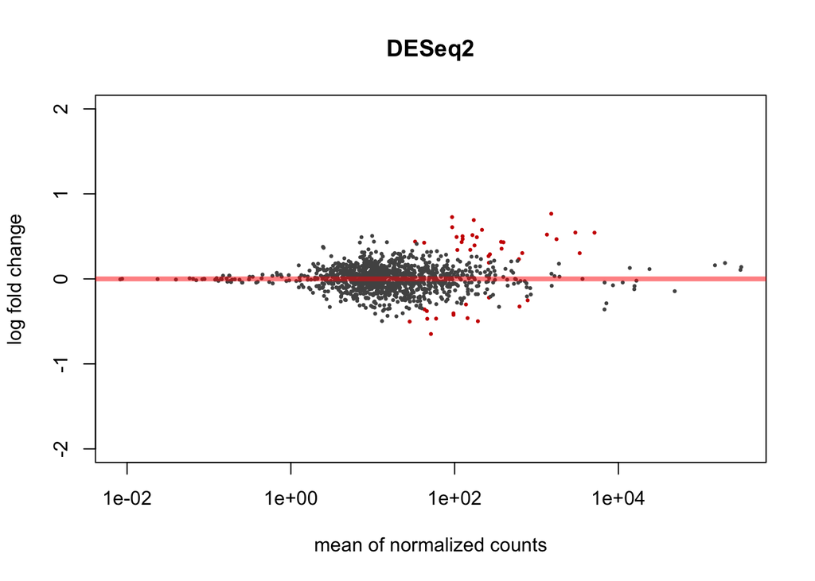

```r
#
# out of 1195 with nonzero total read count
# adjusted p-value < 0.1
# LFC > 0 (up)     : 20, 1.7%
# LFC < 0 (down)   : 24, 2%
# outliers [1]     : 9, 0.75%
# low counts [2]   : 647, 54%
# (mean count < 17)


#################### MODEL NUMBER 6 thru INFINITY - YOUR CHOICE...





################################################################
# Data quality assessment by sample clustering and visualization

plotMA(res, main="DESeq2", ylim=c(-2,2))
```

```r
## Check out one of the genes to see if it's behaving as expected....
d <- plotCounts(dds, gene="TRINITY_DN44744_c1_g2_TRINITY_DN44744_c1_g2_i2_g.17686_m.17686", intgroup=(c("health","day","location")), returnData=TRUE)
d
```

```
##                   count health   day location
## I03_5.08_S_2 130.098207      S day03      int
## I03_5.11_S_4  22.605629      S day06      int
## I07_5.08_S_1   0.500000      S day03      int
## I08_5.08_H_0 105.902501      H day03      int
## I08_5.11_S_1   0.500000      S day06      int
## I08_5.14_S_1   0.500000      S day09      int
## I08_5.17_S_2  36.768858      S day12      int
## I08_5.20_S_3  28.924583      S day15      int
## I09_5.08_H_0 380.842131      H day03      int
## I09_5.14_S_2 128.435270      S day09      int
## I09_5.17_S_2  97.343508      S day12      int
## I09_5.20_S_5   4.437176      S day15      int
## I10_5.08_H_0 522.020025      H day03      int
## I10_5.11_H_0  16.330622      H day06      int
## I10_5.14_H_0  66.617808      H day09      int
## I10_5.17_H_0 246.799698      H day12      int
## I10_5.20_S_2 141.896268      S day15      int
## I14_5.08_S_2 105.305045      S day03      int
## I14_5.11_S_2  37.390508      S day06      int
## I15_5.08_H_0 138.426976      H day03      int
## I15_5.11_H_0  17.854038      H day06      int
## I15_5.14_H_0 161.904180      H day09      int
## I15_5.20_S_3   0.500000      S day15      int
## I19_5.11_H_0 120.040153      H day06      int
## I19_5.14_H_0  41.532003      H day09      int
## I19_5.17_H_0  15.915649      H day12      int
## I19_5.20_S_5   8.847579      S day15      int
## I20_5.08_H_0 211.733654      H day03      int
## I20_5.11_H_0  84.959090      H day06      int
## I20_5.14_H_0 417.594161      H day09      int
## I20_5.17_H_0 180.460458      H day12      int
## I20_5.20_S_2  18.344850      S day15      int
## I22_5.08_S_1   0.500000      S day03      int
## I24_5.11_H_0 312.653959      H day06      int
## I24_5.14_H_0  65.617532      H day09      int
## I24_5.17_H_0 260.347939      H day12      int
## I26_5.08_S_2   0.500000      S day03      int
## I26_5.11_S_3  94.819716      S day06      int
## I27_5.08_H_0  72.556533      H day03      int
```

[output cut: 23 more lines]

```
## I34_6.12_H_0 185.864902      H day03      sub
## I34_6.15_H_0  64.273541      H day06      sub
## I34_6.18_H_0   0.500000      H day09      sub
## I34_6.21_H_0  68.425820      H day12      sub
## I35_6.12_H_0  55.277265      H day03      sub
## I35_6.15_H_0 373.201481      H day06      sub
## I35_6.18_H_0 181.459813      H day09      sub
## I35_6.21_H_0  73.061165      H day12      sub
## I36_6.12_S_1  59.709611      S day03      sub
## I36_6.15_S_2   0.500000      S day06      sub
## I36_6.18_S_3  46.974327      S day09      sub
## I37_6.12_H_0  27.274468      H day03      sub
## I37_6.15_S_1  39.015757      S day06      sub
## I37_6.18_H_0   0.500000      H day09      sub
## I38_6.12_H_0 209.926829      H day03      sub
```

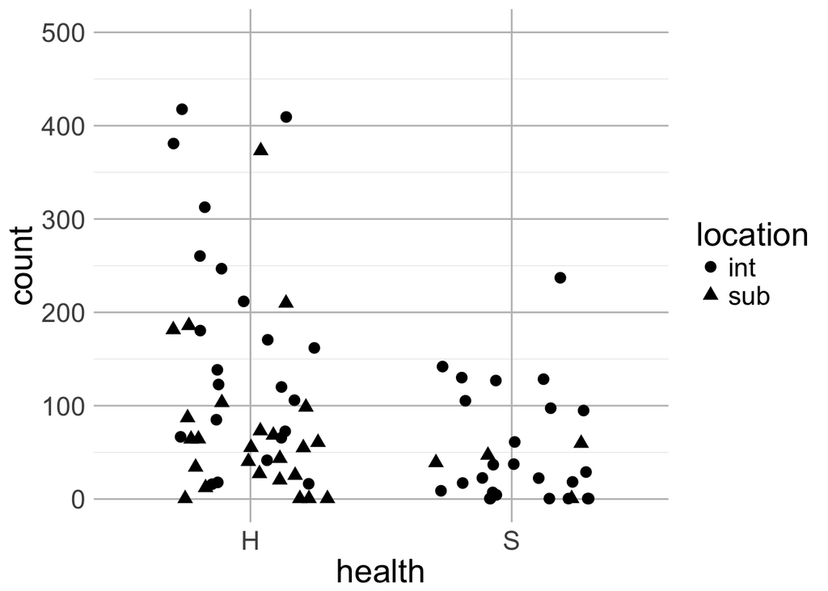

```r
p <- ggplot(d, aes(x= health, y=count, shape = location)) + theme_minimal() + theme(text = element_text(size=20), panel.grid.major = element_line(colour = "grey"))
p <- p + geom_point(position=position_jitter(w=0.3,h=0), size = 3) + ylim(0,500)
p
```

```r
## Check out one of the genes to see interaction between score, health and expression....
d <- plotCounts(dds, gene="TRINITY_DN46245_c3_g3_TRINITY_DN46245_c3_g3_i2_g.21719_m.21719", intgroup=(c("health","score","location")), returnData=TRUE)
d
```

```
##                   count health score location
## I03_5.08_S_2  61.447994      S     2      int
## I03_5.11_S_4  67.821688      S     4      int
## I07_5.08_S_1  53.655741      S     1      int
## I08_5.08_H_0  97.118960      H     0      int
## I08_5.11_S_1  86.874662      S     1      int
## I08_5.14_S_1 102.584759      S     1      int
## I08_5.17_S_2   8.019153      S     2      int
## I08_5.20_S_3  18.265364      S     3      int
## I09_5.08_H_0  82.736137      H     0      int
## I09_5.14_S_2 226.268124      S     2      int
## I09_5.17_S_2  16.042785      S     2      int
## I09_5.20_S_5   4.437176      S     5      int
## I10_5.08_H_0  24.533181      H     0      int
## I10_5.11_H_0 106.791319      H     0      int
## I10_5.14_H_0 209.873058      H     0      int
## I10_5.17_H_0  71.932033      H     0      int
## I10_5.20_S_2  11.662863      S     2      int
## I14_5.08_S_2 179.196371      S     2      int
## I14_5.11_S_2  69.010944      S     2      int
## I15_5.08_H_0 145.923007      H     0      int
## I15_5.11_H_0  83.799384      H     0      int
## I15_5.14_H_0  93.705231      H     0      int
## I15_5.20_S_3  43.802464      S     3      int
## I19_5.11_H_0 297.163672      H     0      int
## I19_5.14_H_0 281.044390      H     0      int
## I19_5.17_H_0  32.432415      H     0      int
## I19_5.20_S_5  34.532437      S     5      int
## I20_5.08_H_0  60.852473      H     0      int
## I20_5.11_H_0  64.118535      H     0      int
## I20_5.14_H_0 159.393014      H     0      int
## I20_5.17_H_0  22.033730      H     0      int
## I20_5.20_S_2  49.077646      S     2      int
## I22_5.08_S_1  93.295923      S     1      int
## I24_5.11_H_0 318.656920      H     0      int
## I24_5.14_H_0 170.051310      H     0      int
## I24_5.17_H_0 447.113646      H     0      int
## I26_5.08_S_2  99.363549      S     2      int
## I26_5.11_S_3  45.466376      S     3      int
## I27_5.08_H_0  58.699507      H     0      int
```

[output cut: 23 more lines]

```
## I34_6.12_H_0 144.453594      H     0      sub
## I34_6.15_H_0 227.638639      H     0      sub
## I34_6.18_H_0 234.563278      H     0      sub
## I34_6.21_H_0 609.568189      H     0      sub
## I35_6.12_H_0 123.241649      H     0      sub
## I35_6.15_H_0 257.417381      H     0      sub
## I35_6.18_H_0 100.103931      H     0      sub
## I35_6.21_H_0 246.934144      H     0      sub
## I36_6.12_S_1  92.838797      S     1      sub
## I36_6.15_S_2  19.573514      S     2      sub
## I36_6.18_S_3 208.833190      S     3      sub
## I37_6.12_H_0  75.468509      H     0      sub
## I37_6.15_S_1 179.716174      S     1      sub
## I37_6.18_H_0 139.594804      H     0      sub
## I38_6.12_H_0 172.889930      H     0      sub
```

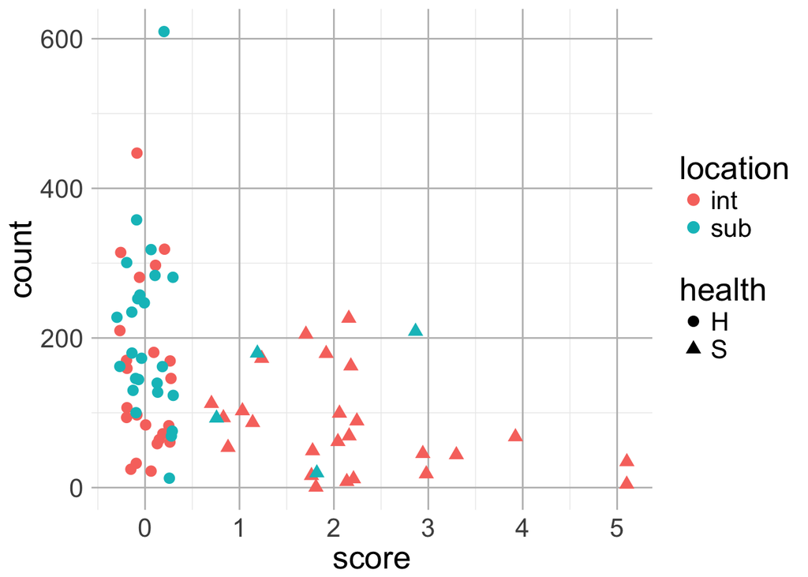

```r
p <- ggplot(d, aes(x= score, y=count, shape = health, color = location)) + theme_minimal() + theme(text = element_text(size=20), panel.grid.major = element_line(colour = "grey"))
p <- p + geom_point(position=position_jitter(w=0.3,h=0), size = 3)
p
```

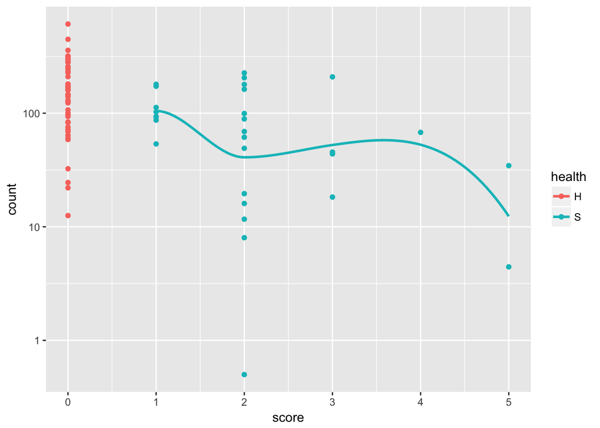

```r
p <- ggplot(d, aes(x=score, y=count, color=health, group=health))
p <- p +  geom_point() + stat_smooth(se=FALSE,method="loess") +  scale_y_log10()
p
```

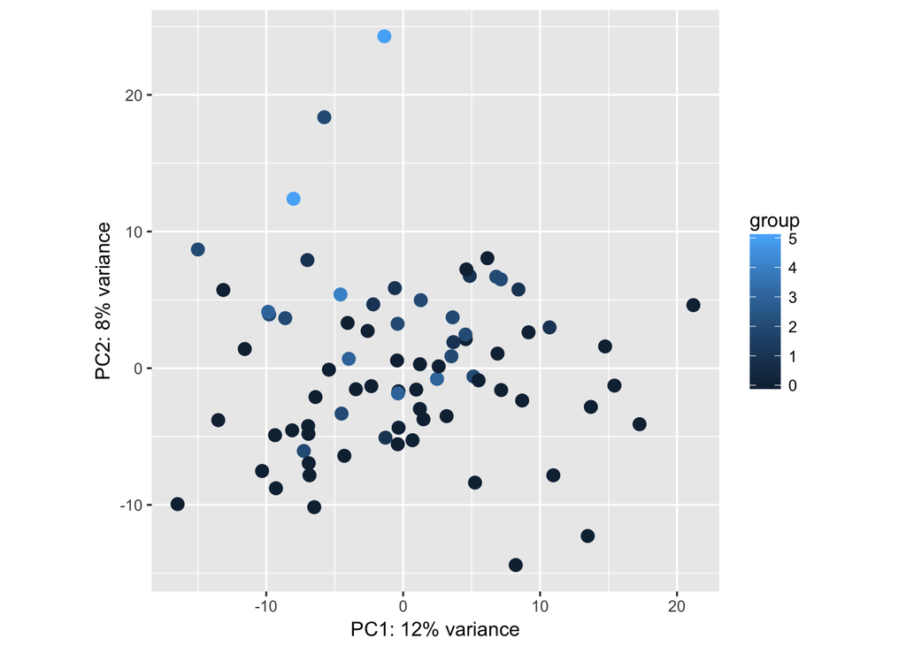

```r
############## PCA plots
vsd <- varianceStabilizingTransformation(dds, blind=FALSE)

plotPCA(vsd, intgroup=c("score"))
```

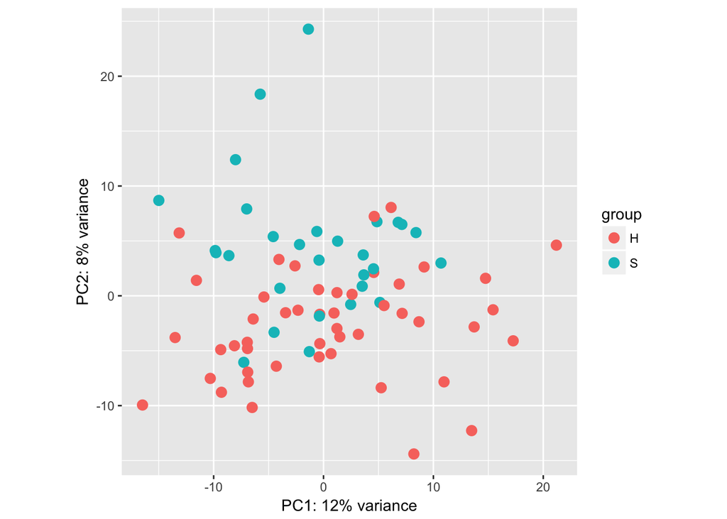

```r
plotPCA(vsd, intgroup=c("health"))
```

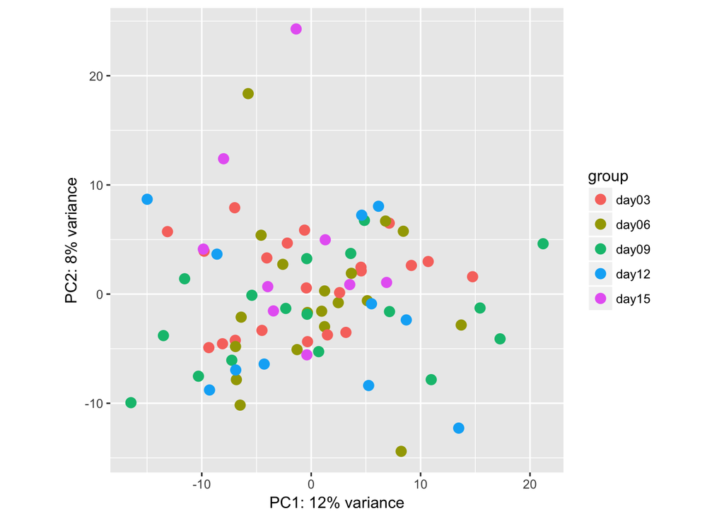

```r
plotPCA(vsd, intgroup=c("day"))
```

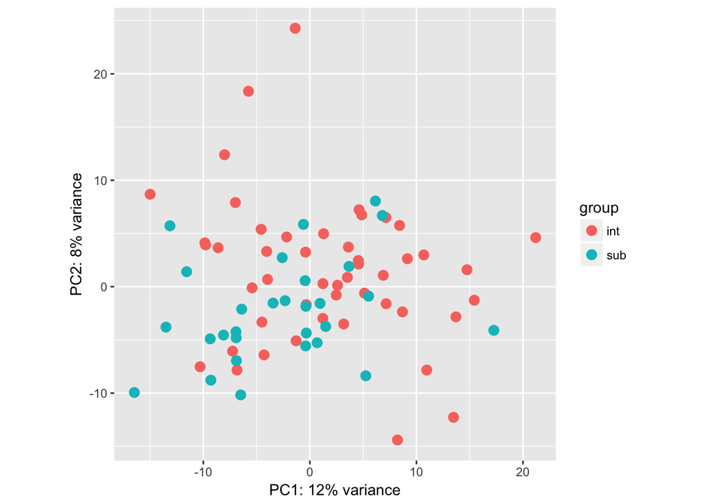

```r
plotPCA(vsd, intgroup=c("location"))
```

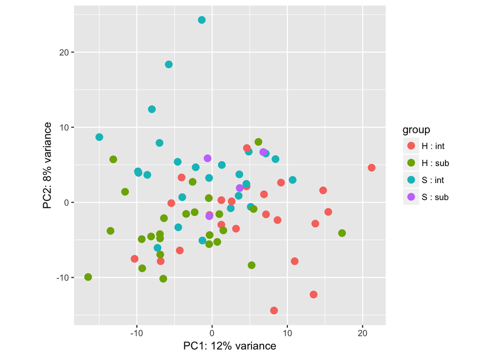

```r
plotPCA(vsd, intgroup=c("health","location"))
```